# Entreprises autour de l’aéroport de Strasbourg

# 1 Constitution de la base

## 1.1 Fichier SIRENE des établissements dans la zone

On commence par interroger la base SIRENE des établissements situés dans les communes concernées : https://www.sirene.fr/sirene/public/creation-fichier.

Les communes demandées sont :

- ENTZHEIM
- HANGENBIETEN
- DUTTLENHEIM
- DUPPIGHEIM
- ERNOLSHEIM-BRUCHE
- HOLTZHEIM
- WOLFISHEIM

Le fichier correspondant est placé dans `data/tables/sirene-all.csv`. La liste des variables est disponible sur : https://www.sirene.fr/sirene/public/static/liste-variables.

## 1.2 Géocodage du fichier SIRENE

On géocode le fichier grâce au service disponible sur https://adresse.data.gouv.fr/csv. Critères :

- numeroVoieEtablissement
- typeVoieEtablissement
- libelleVoieEtablissement
- complementAdresseEtablissement
- codePostalEtablissement
- libelleCommuneEtablissement

Paramètres avancés : code INSEE = codeCommuneEtablissement.

Le fichier correspondant est placé dans `data/tables/sirene-all-geocoded.csv`.

## 1.3 Nettoyage du fichier SIRENE

On importe le fichier `data/tables/sirene-all.geocoded.csv` dans R, en ne garde que les colonnes qui nous intéressent.

Il y a 3929 établissements dans les communes de la zone.

## 1.4 Chiffres d’affaires par SIREN

On récupère les chiffres clés 2019-2018-2017 des entreprises en France sur https://opendata.datainfogreffe.fr/explore/dataset/chiffres-cles-2020 et on les place dans `data/tables/chiffres-cles-2019.csv`. On importe ce fichier dans R, et on le joint au tableau des établissements. (On ne prend pas 2020 parce que beaucoup d’entreprises n’ont pas encore déposé leurs comptes et donc ne sont pas dans le fichier 2020)

## 1.5 Filtres

On enlève les entreprises sans employés, les entreprises unipersonnelles, les entreprises de droit public/administratif, les établissements publics des cultes d’Alsace-Lorraine.

## 1.6 Zones d’activités ciblées

Dans qgis, on dessine les zones d’activité et on enregistre la couche dans `data/spatial/zonesdactivite/zonesdactivite.shp`. Puis on l’importe dans R et on demande les établissements qui sont dans les polygones dessinés.

Il y a 176 établissements ciblés dans les zones d’activité étudiées.

## 1.7 Export

Le fichier des établissements de la zone est exporté dans le fichier `data/tables/etablissements.xlsx`.

# 2 Carte

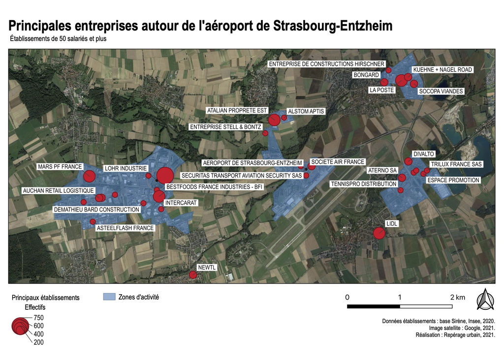

Principales entreprises autour de l’aéroport de Strasbourg

# 3 Statistiques

## 3.1 Dans les communes cibles

### 3.1.1 Domaines d’activité

| **Characteristic** | **N = 201**<sup>1</sup> |
| --- | --- |
| NAF niveau 1 |  |
| Industrie manufacturière | 47 (23%) |
| Commerce ; réparation d'automobiles et de motocycles | 34 (17%) |
| Transports et entreposage | 28 (14%) |
| Activités spécialisées, scientifiques et techniques | 22 (11%) |
| Construction | 22 (11%) |
| Information et communication | 12 (6.0%) |
| Activités de services administratifs et de soutien | 11 (5.5%) |
| Activités financières et d'assurance | 7 (3.5%) |
| Hébergement et restauration | 7 (3.5%) |
| Autres activités de services | 4 (2.0%) |
| Arts, spectacles et activités récréatives | 3 (1.5%) |
| Santé humaine et action sociale | 2 (1.0%) |
| Industries extractives | 1 (0.5%) |
| Production et distribution d'électricité, de gaz, de vapeur et d'air conditionné | 1 (0.5%) |

<sup>*1*</sup> n (%)

### 3.1.2 Effectifs

| **Characteristic** | **N = 201**<sup>1</sup> |
| --- | --- |
| Effectif établissement |  |
| 6 à 9 salariés | 0 (0%) |
| 10 à 19 salariés | 94 (49%) |
| 20 à 49 salariés | 75 (39%) |
| 50 à 99 salariés | 17 (8.9%) |
| 200 à 249 salariés | 0 (0%) |
| 250 à 499 salariés | 5 (2.6%) |
| Unknown | 10 |
| Effectif unité légale |  |
| 6 à 9 salariés | 0 (0%) |
| 10 à 19 salariés | 57 (29%) |
| 20 à 49 salariés | 58 (29%) |
| 50 à 99 salariés | 15 (7.6%) |
| 100 à 199 salariés | 14 (7.1%) |
| 200 à 249 salariés | 7 (3.5%) |
| 250 à 499 salariés | 7 (3.5%) |
| 500 à 999 salariés | 18 (9.1%) |
| 1 000 à 1 999 salariés | 11 (5.6%) |
| 2 000 à 4 999 salariés | 10 (5.1%) |
| 5 000 à 9 999 salariés | 1 (0.5%) |
| Unknown | 3 |

<sup>*1*</sup> n (%)

### 3.1.3 Chiffre d’affaires

| **Characteristic** | **N = 201**<sup>1</sup> |
| --- | --- |
| CA |  |
| Inconnu | 57 (28%) |
| A - de 32K | 14 (7.0%) |
| B entre 32K et 82K | 0 (0%) |
| C entre 82K et 250K | 1 (0.5%) |
| D entre 250K et 1M | 2 (1.0%) |
| E + d 1M | 127 (63%) |

<sup>*1*</sup> n (%)

## 3.2 Dans les zones d’activité cibles

### 3.2.1 Nombre d’établissements

| **Characteristic** | **N = 201**<sup>1</sup> |
| --- | --- |
| Zone d'activité |  |
| Aéroparc | 74 (42%) |
| Plaine de la Bruche | 58 (33%) |
| Aéroport/Hangenbieten | 26 (15%) |
| Joffre | 18 (10%) |
| Unknown | 25 |

<sup>*1*</sup> n (%)

### 3.2.2 Domaines d’activités

| **Characteristic** | Toutes ZA<sup>1</sup> | **Aéroparc**, N = 74<sup>1</sup> | **Aéroport/Hangenbieten**, N = 26<sup>1</sup> | **Joffre**, N = 18<sup>1</sup> | **Plaine de la Bruche**, N = 58<sup>1</sup> |
| --- | --- | --- | --- | --- | --- |
| NAF niveau 1 |  |  |  |  |  |
| Industrie manufacturière | 43 (24%) | 10 (14%) | 6 (23%) | 3 (17%) | 24 (41%) |
| Commerce ; réparation d'automobiles et de motocycles | 29 (16%) | 15 (20%) | 1 (3.8%) | 3 (17%) | 10 (17%) |
| Transports et entreposage | 23 (13%) | 3 (4.1%) | 7 (27%) | 3 (17%) | 10 (17%) |
| Activités spécialisées, scientifiques et techniques | 22 (12%) | 17 (23%) | 4 (15%) | 0 (0%) | 1 (1.7%) |
| Construction | 20 (11%) | 5 (6.8%) | 1 (3.8%) | 4 (22%) | 10 (17%) |
| Information et communication | 12 (6.8%) | 11 (15%) | 1 (3.8%) | 0 (0%) | 0 (0%) |
| Activités de services administratifs et de soutien | 9 (5.1%) | 1 (1.4%) | 4 (15%) | 2 (11%) | 2 (3.4%) |
| Activités financières et d'assurance | 6 (3.4%) | 4 (5.4%) | 0 (0%) | 1 (5.6%) | 1 (1.7%) |
| Autres activités de services | 4 (2.3%) | 3 (4.1%) | 0 (0%) | 1 (5.6%) | 0 (0%) |
| Hébergement et restauration | 3 (1.7%) | 2 (2.7%) | 1 (3.8%) | 0 (0%) | 0 (0%) |
| Arts, spectacles et activités récréatives | 2 (1.1%) | 2 (2.7%) | 0 (0%) | 0 (0%) | 0 (0%) |
| Industries extractives | 1 (0.6%) | 1 (1.4%) | 0 (0%) | 0 (0%) | 0 (0%) |
| Production et distribution d'électricité, de gaz, de vapeur et d'air conditionné | 1 (0.6%) | 0 (0%) | 1 (3.8%) | 0 (0%) | 0 (0%) |
| Santé humaine et action sociale | 1 (0.6%) | 0 (0%) | 0 (0%) | 1 (5.6%) | 0 (0%) |

<sup>*1*</sup> n (%)

### 3.2.3 Effectifs

| **Characteristic** | Toutes ZA<sup>1</sup> | **Aéroparc**, N = 74<sup>1</sup> | **Aéroport/Hangenbieten**, N = 26<sup>1</sup> | **Joffre**, N = 18<sup>1</sup> | **Plaine de la Bruche**, N = 58<sup>1</sup> |
| --- | --- | --- | --- | --- | --- |
| Effectif établissement |  |  |  |  |  |
| 0 salarié au 31/12 (mais dans l'année) | 0 (0%) | 0 (0%) | 0 (0%) | 0 (0%) | 0 (0%) |
| 1 ou 2 salariés | 0 (0%) | 0 (0%) | 0 (0%) | 0 (0%) | 0 (0%) |
| 3 à 5 salariés | 0 (0%) | 0 (0%) | 0 (0%) | 0 (0%) | 0 (0%) |
| 6 à 9 salariés | 0 (0%) | 0 (0%) | 0 (0%) | 0 (0%) | 0 (0%) |
| 10 à 19 salariés | 84 (48%) | 40 (54%) | 14 (54%) | 7 (39%) | 23 (40%) |
| 20 à 49 salariés | 62 (35%) | 27 (36%) | 6 (23%) | 6 (33%) | 23 (40%) |
| 50 à 99 salariés | 17 (9.7%) | 5 (6.8%) | 4 (15%) | 1 (5.6%) | 7 (12%) |
| 100 à 199 salariés | 8 (4.5%) | 2 (2.7%) | 1 (3.8%) | 3 (17%) | 2 (3.4%) |
| 200 à 249 salariés | 0 (0%) | 0 (0%) | 0 (0%) | 0 (0%) | 0 (0%) |
| 250 à 499 salariés | 4 (2.3%) | 0 (0%) | 1 (3.8%) | 1 (5.6%) | 2 (3.4%) |
| 500 à 999 salariés | 1 (0.6%) | 0 (0%) | 0 (0%) | 0 (0%) | 1 (1.7%) |
| 1 000 à 1 999 salariés | 0 (0%) | 0 (0%) | 0 (0%) | 0 (0%) | 0 (0%) |
| 2 000 à 4 999 salariés | 0 (0%) | 0 (0%) | 0 (0%) | 0 (0%) | 0 (0%) |
| 5 000 à 9 999 salariés | 0 (0%) | 0 (0%) | 0 (0%) | 0 (0%) | 0 (0%) |
| 10 000 salariés et plus | 0 (0%) | 0 (0%) | 0 (0%) | 0 (0%) | 0 (0%) |
| Établissement non employeur | 0 (0%) | 0 (0%) | 0 (0%) | 0 (0%) | 0 (0%) |
| Effectif unité légale |  |  |  |  |  |
| 0 salarié au 31/12 (mais dans l'année) | 0 (0%) | 0 (0%) | 0 (0%) | 0 (0%) | 0 (0%) |
| 1 ou 2 salariés | 0 (0%) | 0 (0%) | 0 (0%) | 0 (0%) | 0 (0%) |
| 3 à 5 salariés | 0 (0%) | 0 (0%) | 0 (0%) | 0 (0%) | 0 (0%) |
| 6 à 9 salariés | 0 (0%) | 0 (0%) | 0 (0%) | 0 (0%) | 0 (0%) |
| 10 à 19 salariés | 51 (29%) | 20 (27%) | 9 (35%) | 5 (28%) | 17 (29%) |
| 20 à 49 salariés | 51 (29%) | 24 (32%) | 4 (15%) | 2 (11%) | 21 (36%) |
| 50 à 99 salariés | 15 (8.5%) | 7 (9.5%) | 4 (15%) | 1 (5.6%) | 3 (5.2%) |
| 100 à 199 salariés | 10 (5.7%) | 5 (6.8%) | 0 (0%) | 1 (5.6%) | 4 (6.9%) |
| 200 à 249 salariés | 7 (4.0%) | 1 (1.4%) | 1 (3.8%) | 1 (5.6%) | 4 (6.9%) |
| 250 à 499 salariés | 6 (3.4%) | 4 (5.4%) | 0 (0%) | 1 (5.6%) | 1 (1.7%) |
| 500 à 999 salariés | 15 (8.5%) | 8 (11%) | 1 (3.8%) | 1 (5.6%) | 5 (8.6%) |
| 1 000 à 1 999 salariés | 10 (5.7%) | 3 (4.1%) | 5 (19%) | 0 (0%) | 2 (3.4%) |
| 2 000 à 4 999 salariés | 8 (4.5%) | 2 (2.7%) | 1 (3.8%) | 4 (22%) | 1 (1.7%) |
| 5 000 à 9 999 salariés | 1 (0.6%) | 0 (0%) | 0 (0%) | 1 (5.6%) | 0 (0%) |
| 10 000 salariés et plus | 2 (1.1%) | 0 (0%) | 1 (3.8%) | 1 (5.6%) | 0 (0%) |
| Établissement non employeur | 0 (0%) | 0 (0%) | 0 (0%) | 0 (0%) | 0 (0%) |

<sup>*1*</sup> n (%)

### 3.2.4 Chiffre d’affaires

| **Characteristic** | Toutes ZA<sup>1</sup> | **Aéroparc**, N = 74<sup>1</sup> | **Aéroport/Hangenbieten**, N = 26<sup>1</sup> | **Joffre**, N = 18<sup>1</sup> | **Plaine de la Bruche**, N = 58<sup>1</sup> |
| --- | --- | --- | --- | --- | --- |
| CA |  |  |  |  |  |
| E + d 1M | 113 (64%) | 49 (66%) | 15 (58%) | 11 (61%) | 38 (66%) |
| Inconnu | 48 (27%) | 20 (27%) | 7 (27%) | 6 (33%) | 15 (26%) |
| A - de 32K | 13 (7.4%) | 5 (6.8%) | 3 (12%) | 0 (0%) | 5 (8.6%) |
| C entre 82K et 250K | 1 (0.6%) | 0 (0%) | 1 (3.8%) | 0 (0%) | 0 (0%) |
| D entre 250K et 1M | 1 (0.6%) | 0 (0%) | 0 (0%) | 1 (5.6%) | 0 (0%) |
| B entre 32K et 82K | 0 (0%) | 0 (0%) | 0 (0%) | 0 (0%) | 0 (0%) |

<sup>*1*</sup> n (%)